# Exercício – Testes de Hipóteses para Comparação entre Dois Grupos

# Exercício – Efeito de um medicamento

Um estudo clínico simples avaliou o efeito de um **novo medicamento** na redução da pressão arterial sistólica (em mmHg).

Foram selecionados 20 doentes com hipertensão ligeira, que foram aleatoriamente divididos em dois grupos:

- **Grupo Controlo**: recebeu um placebo.
- **Grupo Tratamento**: recebeu o novo medicamento.

Após 8 semanas, mediu-se a **redução na pressão arterial** (diferença entre a medição inicial e final). Valores positivos indicam diminuição da pressão arterial.

Os dados (em mmHg) são os seguintes:

```r
redução_controlo   <- c(2, 0, 3, -1, 1, 2, 0, 1, -2, 2)
redução_tratamento <- c(5, 7, 4, 6, 3, 8, 5, 6, 4, 7)

redução_controlo
```

```
##  [1]  2  0  3 -1  1  2  0  1 -2  2
```

```r
redução_tratamento
```

```
##  [1] 5 7 4 6 3 8 5 6 4 7
```

Pretende-se testar se o **novo medicamento é mais eficaz** na redução da pressão arterial do que o placebo.

## 1. Exploração inicial dos dados

1. 1. Calcule, para cada grupo, a média, o desvio padrão e o tamanho amostral.

```r
mean(redução_tratamento)
```

```
## [1] 5.5
```

```r
sd(redução_tratamento)
```

```
## [1] 1.581139
```

```r
length(redução_tratamento)
```

```
## [1] 10
```

```r
mean(redução_controlo)
```

```
## [1] 0.8
```

```r
sd(redução_controlo)
```

```
## [1] 1.549193
```

```r
length(redução_controlo)
```

```
## [1] 10
```

2. 2. Faça um **boxplot** comparando os dois grupos e comente, de forma exploratória, se o grupo de tratamento parece ter maior redução da pressão arterial.

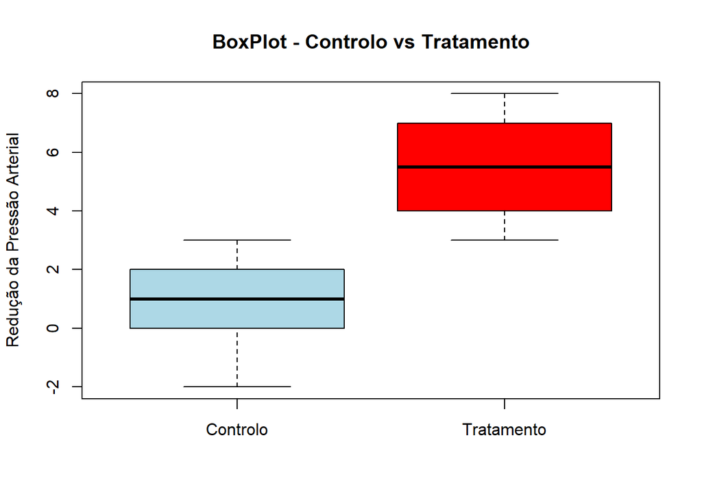

```r
boxplot(list(Controlo = redução_controlo, Tratamento = redução_tratamento),
        col = c("lightblue", "red"),
        ylab = "Redução da Pressão Arterial",
        main = "BoxPlot - Controlo vs Tratamento"
)
```

3. 3. Com base apenas na exploração gráfica e nas estatísticas descritivas, formule uma **hipótese informal** sobre qual dos grupos tem, em média, maior redução da pressão arterial.

> Os dados desceitivos e o gráfico sugerem fortemente que o grupo de Tratamento tem, em média, uma maior redução da pressão arterial do que o grupo de Controlo.

## 2. Formulação das hipóteses estatísticas

1. 1. Formule as hipóteses estatísticas para comparar as **médias populacionais de redução** nos dois grupos:
   - Escreva claramente $H_0$ e $H_1$ em termos de $\mu_C$ (controlo) e $\mu_T$ (tratamento).

   > Seja $\mu_C$ a média populacional da redução da pressão arterial no grupo de controlo e $\mu_T$ a média populacional da redução no grupo de tratamento.

   > Hipótese Nula ($H_0$): O medicamento não tem efeito superior ao placebo.
   > $$H_0 : \mu_T = \mu_C$$
   > Hipótese Alternativa($H_1$): O medicamento é mais eficaz.
   > $$H_1 : \mu_T > \mu_C$$
2. 2. Indique se o teste é **unilateral** ou **bilateral** e justifique a sua escolha com base na pergunta de investigação (“o medicamento é mais eficaz?”).

> O teste é unilateral à direita. Isto porque a pergunta de investigação é direcional: Queremos saber especificamente se o medicamento é mais eficaz, e não apenas se é diferente.

## 3. Condições para o teste t

1. 1. Explique quais são as **principais suposições** do teste t para comparação de duas médias em amostras independentes.

> **Independência**: As observações devem ser independentes dentro de cada grupo e os grupos independentes entre si (garantido pelo desenho experimental aleatorizado).

> **Normalidade**: A variável de resposta (redução da pressão) deve seguir uma distribuição Normal em ambas as populações.

> **Homogeneidade de variâncias**: O teste t clássico assume variâncias iguais, mas o teste de Welch (padrão no R) ajusta para variâncias desiguais.
2. 2. Utilize o R para construir gráficos simples que ajudem a avaliar a plausibilidade da normalidade aproximada em cada grupo.

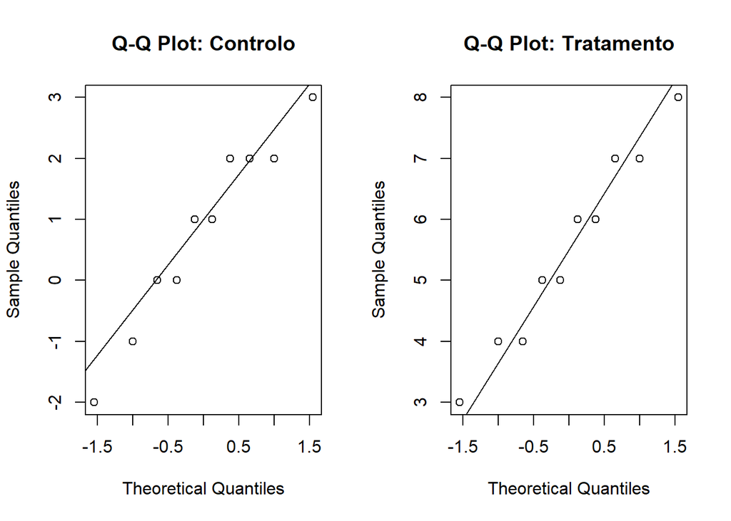

```r
par(mfrow=c(1,2))

qqnorm(redução_controlo, main = "Q-Q Plot: Controlo")
qqline(redução_controlo)

qqnorm(redução_tratamento, main = "Q-Q Plot: Tratamento")
qqline(redução_tratamento)
```

3. 3. Comente, de forma qualitativa, se considera razoável aplicar o teste t a estes dados.

> Dado o tamanho reduzido de amostras, é dificil confirmar a normalidade com certeza. No entanto, os Q-Q plots não mostram desvios grosseiros da linha de referência nem outliners extremos que invalidem completamente o teste. Considera-se razoável prosseguir com os testes t, tendo em conta que este é relativamente robusto a ligeiros desvios da normalidade.

## 4. Teste t para comparação de médias

1. 1. Utilizando o R, aplique um **teste t para amostras independentes** para comparar as médias dos dois grupos.

```r
t.test(redução_tratamento, redução_controlo)
```

```
##
##  Welch Two Sample t-test
##
## data:  redução_tratamento and redução_controlo
## t = 6.7143, df = 17.993, p-value = 2.705e-06
## alternative hypothesis: true difference in means is not equal to 0
## 95 percent confidence interval:
##  3.229311 6.170689
## sample estimates:
## mean of x mean of y
##       5.5       0.8
```

2. 2. Identifique, na saída do R:
   - o valor da estatística de teste t;

   > `t = 6.7143`
   - o $p$-valor.

   > `p-value = 2.705e-06`
3. 3. A um nível de significância $\alpha = 0.05$, qual é a sua **decisão** relativamente a $H_0$?
   - Indique se **rejeita** ou **não rejeita** $H_0$ e justifique com base no $p$-valor.

   > Como o valor de p-value é inferior a 0.05, rejeitamos $H_0$.
4. 4. Interprete o resultado em **linguagem simples**, no contexto do estudo:
   - O que é que os resultados sugerem sobre a eficácia do novo medicamento em comparação com o placebo?

   > Existe evidência estatística muito forte para afirmar que o novo medicamento é mais eficaz do que o placebo na redução de pressão arterial.